# 2 Types of studies

Researchers gather information to make inferences about nature in a variety of settings. Much of statistics deals with **data analysis**, but statistical considerations often play a key role in the planning and design of scientific investigation.

Data in biology are obtained from either an **experimental study** or an **observational study**. In an experimental study, the researcher assigns different treatment groups or values of an explanatory variable randomly to the individual units of study. In an observational study, on the other hand, the researcher has no control over which units fall into which groups.

**NoteExample: Marriage and Life expectancy**

A study found that people who were married are more likely to live longer than single. However, from an **observational** study such as this we don’t know whether marriage increases life expectancy or whether persons who are healthier are more likely to get married.

**NoteExample: Aids as confounder**

Some research has suggested that there is a biological basis for sexual orientation. One such study involved measuring a section of the brain for 40 homosexual men, 40 heterosexual men, and 40 heterosexual women. The research found that the brain section tends to be larger in homosexual men and heterosexual women than in heterosexual men.

Average brain area (mm^2) by group

| group | Brain Area |
| --- | --- |
| Heterosexual men | 11.19 |
| Heterosexual women | 12.01 |
| Homosexual men | 15.15 |

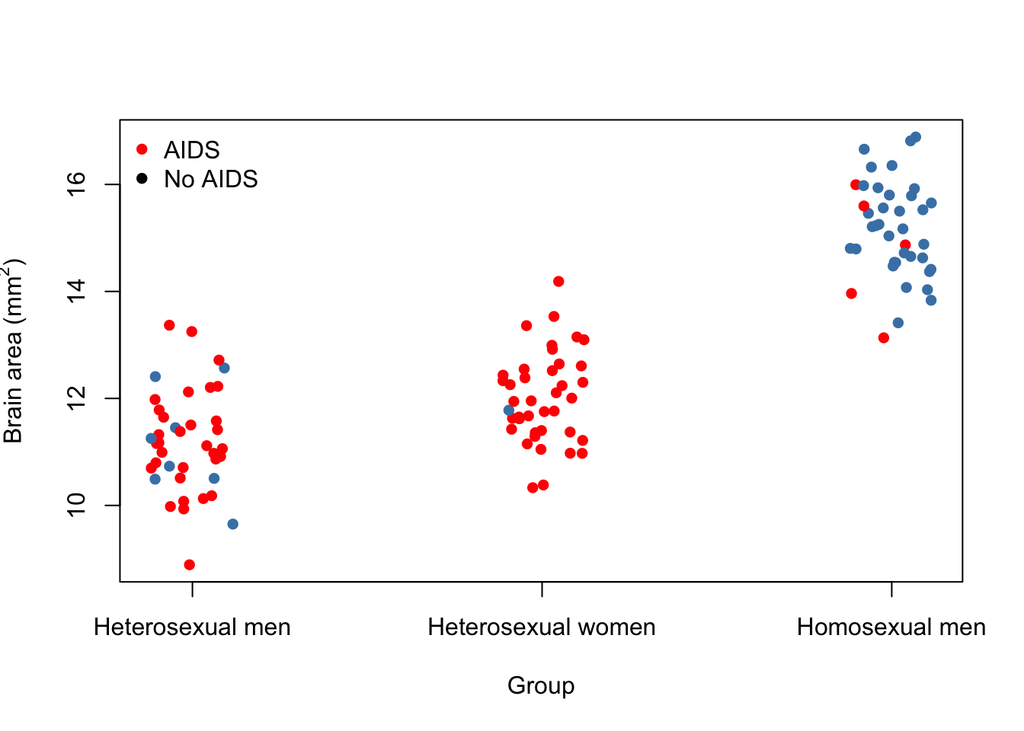

The previous two examples are based on **observational studies**. In an observational study the researcher systematically collects data from subjects, but only as an observer and not as someone who is controling the conditions. However, observational studies can be misleading due to **confounding variables**. The context in which the data arose is important and tell us to be on the alert for the effects that other factors, such as the impact of AIDS, may have on the size of the section of the brain.

**Confounders** are variables, other than the treatment, which are responsible for causing (at least part of) the observed difference in the outcome between the various levels of the treatment.

**How can we mitigate confounding?** Create treatment and control groups that are as similar as possible except for the treatment level and we can anticipate and prevent both other known and unknown explanations for the observed difference in outcomes between the treated and control groups.

**NoteExample: Effect of drug on cats**

Summary by Sex and Dose

| Sex | Mean (2mg) | Mean (6mg) |
| --- | --- | --- |
| Female | 129.0132 | 157.5753 |
| Male | 142.0265 | 120.2499 |

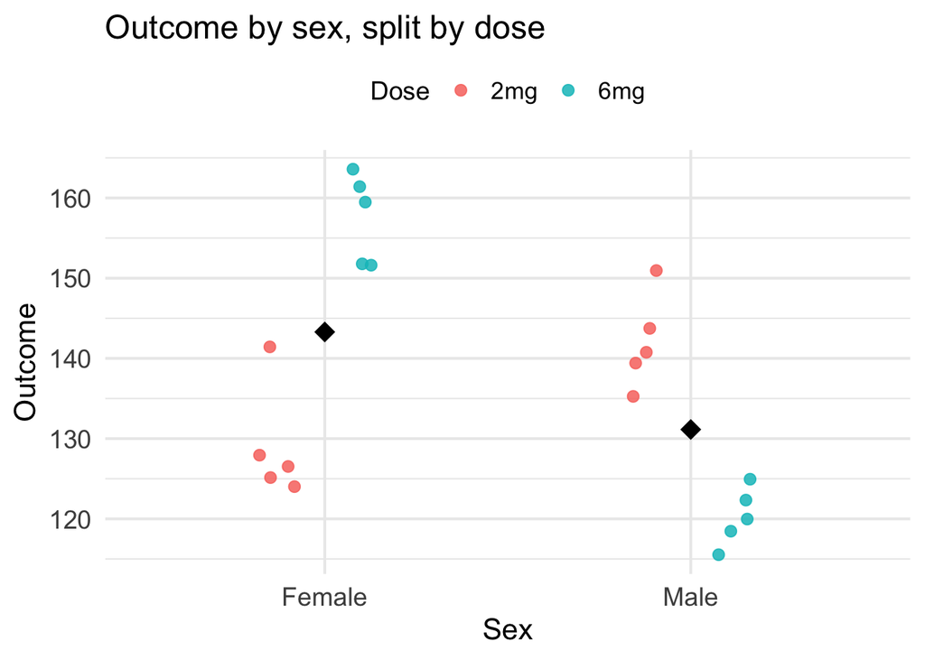

Often, human subjects in experiments are given a **placebo**. Of course, if a placebo control is used, then the subjects must not be told which group they are in, that is, the experiment is **blinded**. The purpose of blinding is to minimize the extent to which subject expectations influence the results of the experiment. If subjects exhibit a psychological reaction to getting a medication, that placebo response will tend to balance out between the two groups, so that any difference between the groups can be attributed to the effect of the active treatment.

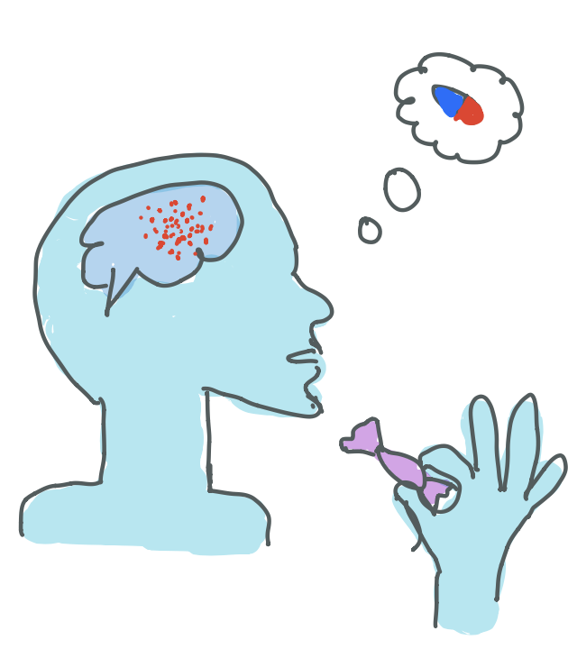

Placebo

How about the person evaluating the responses? This person can be subject to bias influencing the observation process itself. An experiment in which both the subjects and the persons making the evaluations of the response are blinded is called **double-blinded**.

Randomized allocation in medical settings may not be ethical. One possibility is to use **historical controls** (i.e. previous patients with the same illnes who were treated with another therapy). The challenge is that overall characteristics of the patients may change with time. A possible solution is to do some statistical adjustment to control for differences in characteristics (for example age).

**Random Sampling**

**Exploratory Data Analysis (EDA)**

**Confirmatory Data Analysis (CDA)**

See Knuth (1984) for additional discussion of literate programming.

Knuth, Donald E. 1984. “Literate Programming.” *Comput. J.* (USA) 27 (2): 97–111. https://doi.org/10.1093/comjnl/27.2.97.